# Thermal Hardiness Assays in D. melanogaster

Hannah Chu

2018-06-11

[Back](https://adnguyen.github.io/Hahn_lab_protocols/) to main page

# General info and notes before starting

- There are 13 water bath tubes set up to examine 13 [DSPR founder lines](http://wfitch.bio.uci.edu/~dspr/RILs/index.html) of drosophila melanogaster:

[figure not shown]

| Lines | Vial Code/Stock Number | Stock Name | # of Vials received 2018-06-12 |
| --- | --- | --- | --- |
| AB8 | Sam | n/a | 3 |
| A5 | 3875 | VAG1 | 2 |
| A7 | T.7/14021-0231.7 | n/a | 2 |
| A2 | 3841 | BOG1 | 2 |
| B6 | T.1/14021-0231.1 | n/a | 2 |
| B7 | T.4/14021-0231.4 | n/a | 2 |
| A4 | 3852 | KSA2 | 2 |
| A6 | 3886 | wild5B | 2 |
| A3 | 3844 | BS1 | 2 |
| B2 | 3846 | CA1 | 2 |
| B3 | 3864 | QI2 | 2 |
| A1 | 1 | Canton-S | 2 |
| B4 | 3870 | RVC3 | 2 |

# Machines, Apparatus, & Instruments

**Water Bath**: LAUDA ECO Silver Immersion thermostat, Model ECO RE 1050 S

[figure not shown]

- Catalog No. LCK 4918
- [Website](http://www.capitolscientific.com/LAUDA-LCK-4918-Model-ECO-RE-1050-S-Stainless-Steel-Refrigerated-Circulator-Bath-with-ECO-Silver-Th)
- [Manual](http://www.lauda-brinkmann.com/downloads/manuals/Eco%20Silver.pdf)

**Thermocoupler**: Omega HH506RA Multilogger Thermometer

[figure not shown]

- Model No. HH506RA
- [Website](https://www.omega.com/pptst/HH506A_HH506RA.html)
- [Specs](https://www.omega.com/temperature/pdf/HH506A_HH506RA.pdf)
- [Manual](https://www.omega.com/manuals/manualpdf/M4079.pdf)

**Glass Test tubes**: Pyrex No. 9826

[figure not shown]

- Manufacturing No.: Corning, 9826-16, O.D. × L 16 mm × 100 mm
- [Website](https://www.sigmaaldrich.com/catalog/product/aldrich/cls982616?lang=en&region=US)

**Test tube rack**: Full-View Test Tube Rack, 13-16mm tubes, 50 Place

- Manufactoring No. H18911-0000
- [Website](https://www.supplymylab.com/Supplies/Racks/_/PIN-STYLE-TEST-TUBE-RACKS?=&gclid=CjwKCAjwsJ3ZBRBJEiwAtuvtlFGpJXjTFulK0gRzhGnNBXTrayx-hRXRtmuEZQ2NUpUmFCEtH8zjHRoCAGsQAvD_BwE)

**Tube Set Up**: Cut half of a styrofoam falcon tube rack and hot clue to plastic test tube rack

- [top view](https://user-images.githubusercontent.com/26017826/42095435-9981db5a-7b80-11e8-8269-f18319ef5414.JPG)
- [front view](https://user-images.githubusercontent.com/26017826/42095436-99958790-7b80-11e8-8465-0c7d15f0e6b9.JPG)
- [side view](https://user-images.githubusercontent.com/26017826/42095437-99b81742-7b80-11e8-9981-df9263372799.JPG)

**Aspirator Set up**

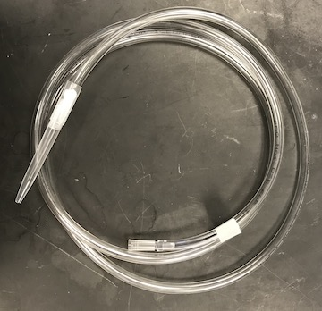

- Vinyl Tubing: Watts Clear Vinyl Tubing 8mm OD x 5mm ID
- [Buy](https://www.amazon.com/Clear-Vinyl-Tubing-ID-250/dp/B000H5WQXC)
- Ref. No.: 443063/LSVEB20
- Pipette tip for mouthpiece: 20uL
- Pipette tip for Drosophila: 1000uL
- Note: Place [mesh](https://www.amazon.com/Mosquito-Barrier-Hunting-Netting-Protect/dp/B015ADBL4U/ref=sr_1_10?ie=UTF8&qid=1529090596&sr=8-10&keywords=mosquito+netting+fabric) in 1000uL pipette tip to prevent inhaling fly.

# Protocol

## 1. CTmax Slow Ramp

```
* Using the WinTherm-Thermal Analytics Software, set parameters as below
```

| Temp (ºC) | Time (min) | Tol (ºC) | Pump |
| --- | --- | --- | --- |
| 25.1 | 5 | 0 | 2 |
| 25.2 | 1 | 0 | 2 |
| 25.3 | 1 | 0 | 2 |
| 25.4 | 1 | 0 | 2 |
| 25.5 | 1 | 0 | 2 |
| 25.6 | 1 | 0 | 2 |
| 25.7 | 1 | 0 | 2 |
| 25.8 | 1 | 0 | 2 |
| 25.9 | 1 | 0 | 2 |
| 26.0 | 1 | 0 | 2 |
| 26.1 | 1 | 0 | 2 |
| 26.2 | 1 | 0 | 2 |
| 26.3 | 1 | 0 | 2 |
| 26.4 | 1 | 0 | 2 |
| 26.5 | 1 | 0 | 2 |
| 26.6 | 1 | 0 | 2 |
| 26.7 | 1 | 0 | 2 |
| 26.8 | 1 | 0 | 2 |
| 26.9 | 1 | 0 | 2 |
| 27.0 | 1 | 0 | 2 |
| 27.1 | 1 | 0 | 2 |
| 27.2 | 1 | 0 | 2 |
| 27.3 | 1 | 0 | 2 |
| 27.4 | 1 | 0 | 2 |
| 27.5 | 1 | 0 | 2 |
| 27.6 | 1 | 0 | 2 |
| 27.7 | 1 | 0 | 2 |
| 27.8 | 1 | 0 | 2 |
| 27.9 | 1 | 0 | 2 |
| 28.0 | 1 | 0 | 2 |

[output cut: 120 more lines]

1. Submerge apparatus into water bath.
2. Press start on the WinTherm-Thermal Analytics Software and click OK to confirm.
3. Check the flies once an hour for 2 hours. Once the temperature reaches 38.5ºC, observe fly knockdown.

## 2. CTmax Fast Ramp

```
* Using the WinTherm-Thermal Analytics Software, set parameters as below
```

| Temp (ºC) | Time (min) | Tol (ºC) | Pump |
| --- | --- | --- | --- |
| 25 | 5 | 0 | 2 |
| 26 | 1 | 0 | 2 |
| 27 | 1 | 0 | 2 |
| 28 | 1 | 0 | 2 |
| 29 | 1 | 0 | 2 |
| 30 | 1 | 0 | 2 |
| 31 | 1 | 0 | 2 |
| 32 | 1 | 0 | 2 |
| 33 | 1 | 0 | 2 |
| 34 | 1 | 0 | 2 |
| 35 | 1 | 0 | 2 |
| 36.5 | 1 | 0 | 2 |
| 37.5 | 1 | 0 | 2 |
| 38.5 | 1 | 0 | 2 |
| 40 | 200 | 0 | 2 |

1. Submerge apparatus into water bath.
2. Press start on the WinTherm-Thermal Analytics Software and click OK to confirm.

## 3. Static

1. Using the WinTherm-Thermal Analytics Software, imput desired temperature into “set temp” box and press enter.
2. Submerge apparatus into water bath for 200 minutes.

## 4. Hardening

1. Using the WinTherm-Thermal Analytics Software, input first desired temperature into “set temp” box and press enter.
2. Submerge apparatus into water bath for 60 minutes.
3. Remove the apparatus for 5 minutes
4. Input second desired temperature into “set temp” box and press enter.
5. Re-insert the apparatus into the water bath for 200min.